# 08-coverage-probability

Soyeon Park

11/14/2020

In this post, I am going to perform a simulation to calculate the coverage probability of the 95% confidence interval of the median when computed from *F̂*<sub>*X*</sub><sup>*m**l**e*</sup>. For the purpose of the post, I defined the 95% confidence interval of the median to be the middle 95% of sampling distribution of the median. Moreover, I defined the coverage provability as the long run proportion of intervals that capture the population parameter of interest.

## First step

I am going to generate a single sample from a standard normal distribution of size *N* = 201.

```r
library(tidyverse)
library(stats4)

N = 201
data = rnorm(N)
```

I am going to use Maximum Likelihood Estimation(MLE) to estimate the distribution. Let’s say we think that the data I generated above might be normally distributed. After calculating log likelihood, I am going to find the best mean and standard deviation, both of which have the maximum likelihood, for this one sample data.

```r
# Log likelihood for normal distribution
nll <- function(mean, sd) {
  fs <- dnorm(x = data, mean, sd, log = TRUE)
  -sum(fs)
}

# Find a mean and standard deviation which has the maximum likelihood
fit_norm <- mle(
  nll,
  start = list(mean = mean(data), sd = sqrt(var(data))),
  method = "L-BFGS-B",
  lower = c(0, 0.01)
)

coef(fit_norm)
```

```
##     mean       sd
## 0.000000 1.000076
```

Let’s look at the sample’s estimated PDF onto histogram

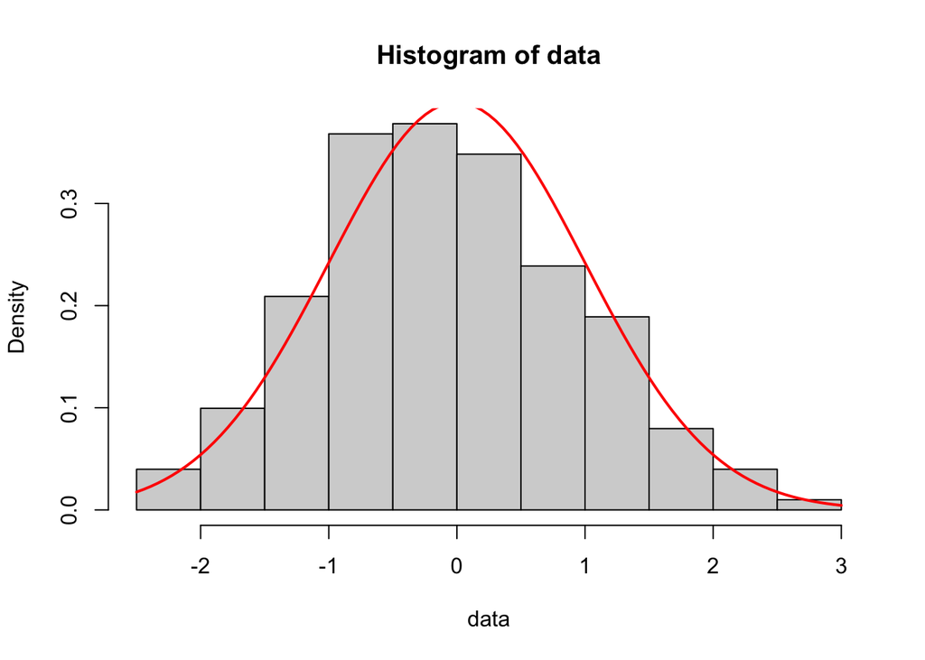

```r
hist(data, freq = FALSE)
curve(dnorm(x, mean = coef(fit_norm)[1], sd = coef(fit_norm)[2]), add = TRUE, col = "red", lwd = 2)
```

## Second step

I am going to show how I approximate the sampling distribution of the median, conditional on the estimate of the distribution in the previous step. In order to get 5000 medians from the sample, I used B + Q method.

```r
n = 5000
# B+Q method
meds = rbeta(n, 101, 101) %>% qnorm(mean = coef(fit_norm)[1], sd = coef(fit_norm)[2])
```

Another way which substitutes for the code above is using a for loop. However, as B+Q method is much faster than for loop, I used the code above.

```r
n = 5000
medsAnotherWay = NA
for(i in 1:n){
  re.samp = rnorm(N, mean = coef(fit_norm)[1], sd = coef(fit_norm)[2])
  medsAnotherWay[i] = median(re.samp)
}
```

Let’s see the histogram of medians.

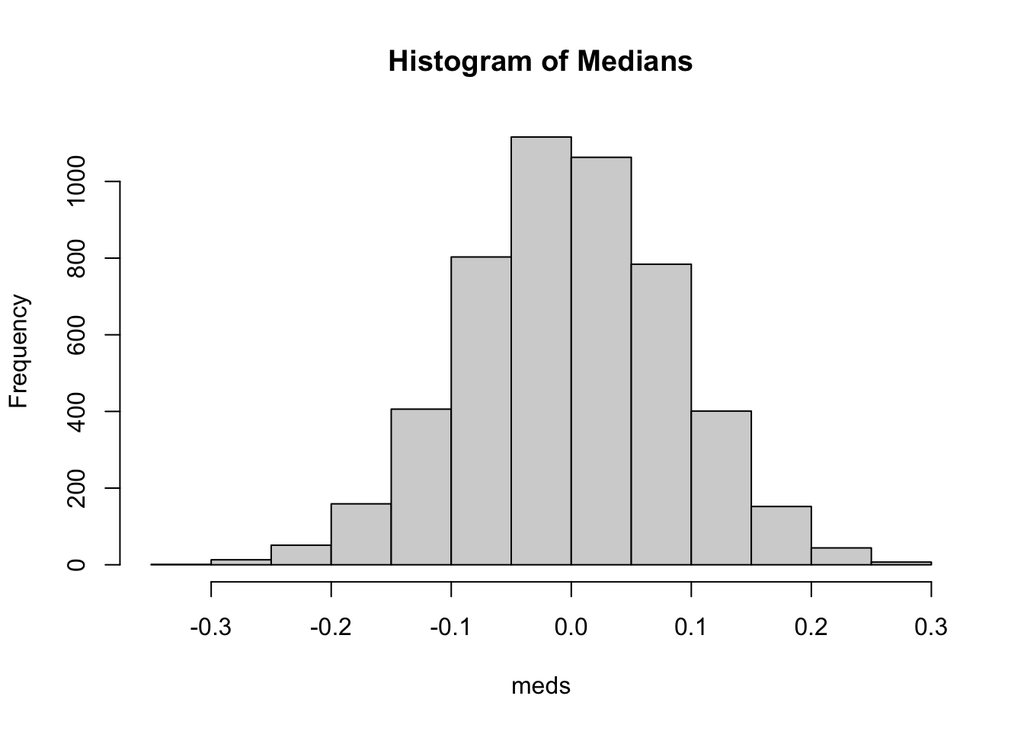

```r
hist(meds, main = "Histogram of Medians")
```

## Third step

Let’s calculate a 95% confidence interval from the approximated sampling distribution. Since I am interested in the middle 95% confidence interval, I am going to calculate the 2.5th and 97.5th percentile of the sampling distribution called `meds` by using the `quantile` function.

```r
# confidence interval
ci = quantile(meds, c(0.025, 0.975))
ci
```

```
##       2.5%      97.5%
## -0.1760904  0.1683152
```

## Fourth step

Finally, I am going to calculate the coverage probability.

Here is what my code below is going to do. It generates a single sample from a standard normal distribution of size 201(N). This is original sample data. Using MLE method, we generate 201 sample data and calculate the median of this sample(Bootstrap), and repeats these steps 100(n) times. Then we have 100(n) medians from the sampling distribution. Find a confidence interval and check whether the interval includes population’s parameter of interest(In this simulation, the population’s parameter of interest is 0). Simulate these steps 1000 times. Finally, we get 1000 intervals and calculate the proportion of intervals that capture the population parameter of interest.

```r
gen.ci.med = function(n = 100, N = 201, parm.int = 0) {
  data = rnorm(N)

  normal.ll <- function(mean, sd){
    fs <- dnorm(x = data, mean = mean, sd = sd, log = TRUE)
    -sum(fs)
  }

  fit_norm <- mle(
    normal.ll,
    start = list(mean = mean(data), sd = sqrt(var(data))),
    method = "L-BFGS-B",
    lower = c(0, 0.01)
  )

  mean = coef(fit_norm)[1]
  sd = coef(fit_norm)[2]

  meds = rbeta(n, 101, 101) %>% qnorm(mean = coef(fit_norm)[1], sd = coef(fit_norm)[2])

  ci = quantile(meds, c(0.025, 0.975))
  return (ci[1] < parm.int & ci[2] > parm.int)
}

ci.contain = NA
repeat_num = 1000
for(i in 1:repeat_num){
  ci.contain[i] = gen.ci.med()
}

mean(ci.contain)
```

```
## [1] 0.985
```

## Additional Question

Q. How I might change the simulation to learn more about the operating characteristics of my chosen method for constructing the 95% confidence interval?

In this simulation, there are two variables we can change: `n`(the number of bootstrap samples) and `repeat_num`(the number of simulation or the number of intervals). For people who think N is also a variable, we cannot change N in reality. N stands for the size of original sample data. In reality, original sample data is already set, which means we can’t control it.

First of all, let’s change the variable `n`(the number of bootstrap samples). Let’s increase the variable to 1000.

```r
gen.ci.med = function(n = 1000, N = 201, parm.int = 0) {
  data = rnorm(N)

  normal.ll <- function(mean, sd){
    fs <- dnorm(x = data, mean = mean, sd = sd, log = TRUE)
    -sum(fs)
  }

  fit_norm <- mle(
    normal.ll,
    start = list(mean = mean(data), sd = sqrt(var(data))),
    method = "L-BFGS-B",
    lower = c(0, 0.01)
  )

  mean = coef(fit_norm)[1]
  sd = coef(fit_norm)[2]

  meds = rbeta(n, 101, 101) %>% qnorm(mean = coef(fit_norm)[1], sd = coef(fit_norm)[2])

  ci = quantile(meds, c(0.025, 0.975))
  return (ci[1] < parm.int & ci[2] > parm.int)
}

ci.contain = NA
repeat_num = 1000
for(i in 1:repeat_num){
  ci.contain[i] = gen.ci.med()
}

mean(ci.contain)
```

```
## [1] 0.991
```

```r
gen.ci.med = function(n = 10, N = 201, parm.int = 0) {
  data = rnorm(N)

  normal.ll <- function(mean, sd){
    fs <- dnorm(x = data, mean = mean, sd = sd, log = TRUE)
    -sum(fs)
  }

  fit_norm <- mle(
    normal.ll,
    start = list(mean = mean(data), sd = sqrt(var(data))),
    method = "L-BFGS-B",
    lower = c(0, 0.01)
  )

  mean = coef(fit_norm)[1]
  sd = coef(fit_norm)[2]

  meds = rbeta(n, 101, 101) %>% qnorm(mean = coef(fit_norm)[1], sd = coef(fit_norm)[2])

  ci = quantile(meds, c(0.025, 0.975))
  return (ci[1] < parm.int & ci[2] > parm.int)
}

ci.contain = NA
repeat_num = 1000
for(i in 1:repeat_num){
  ci.contain[i] = gen.ci.med()
}

mean(ci.contain)
```

```
## [1] 0.937
```

Second, let’s control `repeat_num`(the number of simulation or the number of intervals). In the simulation above, I simulated 1000 times. Let’s increase the number of simulation into 10000.

```r
gen.ci.med = function(n = 100, N = 201, parm.int = 0) {
  data = rnorm(N)

  normal.ll <- function(mean, sd){
    fs <- dnorm(x = data, mean = mean, sd = sd, log = TRUE)
    -sum(fs)
  }

  fit_norm <- mle(
    normal.ll,
    start = list(mean = mean(data), sd = sqrt(var(data))),
    method = "L-BFGS-B",
    lower = c(0, 0.01)
  )

  mean = coef(fit_norm)[1]
  sd = coef(fit_norm)[2]

  meds = rbeta(n, 101, 101) %>% qnorm(mean = coef(fit_norm)[1], sd = coef(fit_norm)[2])

  ci = quantile(meds, c(0.025, 0.975))
  return (ci[1] < parm.int & ci[2] > parm.int)
}

ci.contain = NA
repeat_num = 10000
for(i in 1:repeat_num){
  ci.contain[i] = gen.ci.med()
}

mean(ci.contain)
```

```
## [1] 0.9881
```

It turns out that there is no big change in coverage probability when you increase the number of simulation. Then, this time, let’s decrease it into 100.

```r
gen.ci.med = function(n = 100, N = 201, parm.int = 0) {
  data = rnorm(N)

  normal.ll <- function(mean, sd){
    fs <- dnorm(x = data, mean = mean, sd = sd, log = TRUE)
    -sum(fs)
  }

  fit_norm <- mle(
    normal.ll,
    start = list(mean = mean(data), sd = sqrt(var(data))),
    method = "L-BFGS-B",
    lower = c(0, 0.01)
  )

  mean = coef(fit_norm)[1]
  sd = coef(fit_norm)[2]

  meds = rbeta(n, 101, 101) %>% qnorm(mean = coef(fit_norm)[1], sd = coef(fit_norm)[2])

  ci = quantile(meds, c(0.025, 0.975))
  return (ci[1] < parm.int & ci[2] > parm.int)
}

ci.contain = NA
repeat_num = 100
for(i in 1:repeat_num){
  ci.contain[i] = gen.ci.med()
}

mean(ci.contain)
```

```
## [1] 0.99
```

In conclusion, the number of simulation does not give a big impact on the coverage probability, while the number of bootstrap sample change the coverage probability. The more bootstrap samples we have, the higher the coverage probability we can get.